# PointNet

This is an implementation of [PointNet: Deep Learning on Point Sets for 3D Classification and Segmentation](https://arxiv.org/abs/1612.00593) using PyTorch.

## Getting started

Don't forget to turn on GPU if you want to start training directly.

**Runtime** -> **Change runtime type**-> **Hardware accelerator**

```python
!pip install plyfile;
!pip install path.py;
import numpy as np
import math
import random
import os
import torch
import scipy.spatial.distance
import pandas as pd
import plotly.graph_objects as go
import plotly.express as px
from google.colab import drive

from torch.utils.data import Dataset, DataLoader
from torchvision import transforms, utils
from path import Path
from plyfile import PlyData
from scipy.spatial import Delaunay, QhullError
```

```python
random.seed = 42
```

```python
import zipfile
drive.mount('/content/drive', force_remount=True)
zip_path = '/content/drive/My Drive/dataset_ply.zip'  # Replace with your path
extract_to = '/content/my_dataset'  # Or any folder you like

with zipfile.ZipFile(zip_path, 'r') as zip_ref:
    zip_ref.extractall(extract_to)
#!unzip -q dataset.zip;

path = Path("/content/my_dataset/dataset_ply")
```

```python
folders = [dir for dir in sorted(os.listdir(path)) if os.path.isdir(path/dir)]
classes = {folder: i for i, folder in enumerate(folders)};
classes
```

```
{'else': 0, 'stump': 1, 'terrain': 2}
```

We will need a function to read this type of files:

```python
def read_ply(file_path):
    plydata = PlyData.read(file_path)

    # Extract vertices
    vertex_data = plydata['vertex']
    verts = np.vstack([vertex_data[t] for t in ('x', 'y', 'z')]).T.tolist()

    # Check and extract/generate faces
    if 'face' in plydata:
        face_data = plydata['face'].data
        faces = [list(face[0]) for face in face_data]
    else:
        # Generate faces using 2D Delaunay triangulation on XY plane
        try:
            xy = np.vstack([vertex_data[t] for t in ('x', 'y')]).T
            tri = Delaunay(xy)
            faces = tri.simplices.tolist()
        except QhullError:
            #print(f"[Warning] Delaunay failed for: {file_path.name} — using empty face list")
            faces = []

    # Ensure faces is not empty and create dummy faces if necessary
    if not faces:
        # Create dummy faces (e.g., using the first few vertices) if no valid faces
        faces = [[i, i+1, i+2] for i in range(min(len(verts) - 2, 3))]

    return verts, faces
```

```python
# Correct usage — no need to open the file manually
verts, faces = read_ply(path / "terrain/train/cell_2_5.ply")
```

```python
i,j,k = np.array(faces).T
x,y,z = np.array(verts).T
```

```python
len(x)
```

```
4043
```

Don't be scared of this function. It's just to display animated rotation of meshes and point clouds.

```python
def visualize_rotate(data):
    x_eye, y_eye, z_eye = 1.25, 1.25, 0.8
    frames=[]

    def rotate_z(x, y, z, theta):
        w = x+1j*y
        return np.real(np.exp(1j*theta)*w), np.imag(np.exp(1j*theta)*w), z

    for t in np.arange(0, 10.26, 0.1):
        xe, ye, ze = rotate_z(x_eye, y_eye, z_eye, -t)
        frames.append(dict(layout=dict(scene=dict(camera=dict(eye=dict(x=xe, y=ye, z=ze))))))
    fig = go.Figure(data=data,
                    layout=go.Layout(
                        updatemenus=[dict(type='buttons',
                                    showactive=False,
                                    y=1,
                                    x=0.8,
                                    xanchor='left',
                                    yanchor='bottom',
                                    pad=dict(t=45, r=10),
                                    buttons=[dict(label='Play',
                                                    method='animate',
                                                    args=[None, dict(frame=dict(duration=50, redraw=True),
                                                                    transition=dict(duration=0),
                                                                    fromcurrent=True,
                                                                    mode='immediate'
                                                                    )]
                                                    )
                                            ]
                                    )
                                ]
                    ),
                    frames=frames
            )

    return fig
```

```python
visualize_rotate([go.Mesh3d(x=x, y=y, z=z, color='lightpink', opacity=0.50, i=i,j=j,k=k)]).show()
```

[interactive chart not shown]

```python
visualize_rotate([go.Scatter3d(x=x, y=y, z=z,
                                   mode='markers')]).show()
```

[interactive chart not shown]

First things first, let's write a function to accurately visualize point clouds so we could see vertices better.

```python
def pcshow(xs,ys,zs):
    data=[go.Scatter3d(x=xs, y=ys, z=zs,
                                   mode='markers')]
    fig = visualize_rotate(data)
    fig.update_traces(marker=dict(size=2,
                      line=dict(width=2,
                      color='DarkSlateGrey')),
                      selector=dict(mode='markers'))
    fig.show()
```

```python
pcshow(x,y,z)
```

[interactive chart not shown]

## Transforms

### Sample points

```python
class PointSampler(object):
    def __init__(self, output_size):
        assert isinstance(output_size, int)
        self.output_size = output_size

    def triangle_area(self, pt1, pt2, pt3):
        side_a = np.linalg.norm(pt1 - pt2)
        side_b = np.linalg.norm(pt2 - pt3)
        side_c = np.linalg.norm(pt3 - pt1)
        s = 0.5 * ( side_a + side_b + side_c)
        return max(s * (s - side_a) * (s - side_b) * (s - side_c), 0)**0.5

    def sample_point(self, pt1, pt2, pt3):
        # Barycentric coordinates on a triangle
        s, t = sorted([random.random(), random.random()])
        f = lambda i: s * pt1[i] + (t - s) * pt2[i] + (1 - t) * pt3[i]
        return (f(0), f(1), f(2))

    def __call__(self, mesh):
        verts, faces = mesh
        verts = np.array(verts)
        areas = np.zeros((len(faces)))

        # Calculate triangle areas (weights for sampling)
        for i in range(len(areas)):
            areas[i] = self.triangle_area(verts[faces[i][0]],
                                          verts[faces[i][1]],
                                          verts[faces[i][2]])

        # Ensure that the areas/weights sum to a positive value
        total_area = sum(areas)

        # If total_area is zero or negative, skip the mesh and return None
        if total_area <= 0:
            #print(f"[Warning] Delaunay failed for: {mesh} — using empty face list")
            return None  # Skip this file and return None

        # Normalize areas to avoid any issues with zero or negative weights
        areas = np.array(areas) / total_area

        # Check if sum of weights is positive and greater than zero
        if sum(areas) <= 0:
            print(f"[Warning] Skipping file with invalid weights for: {mesh}")
            return None  # Skip if weights are invalid

        # Now sample points based on the areas
        sampled_faces = random.choices(faces, weights=areas, cum_weights=None, k=self.output_size)

        # Sample the actual points from the selected faces
        sampled_points = np.zeros((self.output_size, 3))
        for i in range(len(sampled_faces)):
            sampled_points[i] = self.sample_point(verts[sampled_faces[i][0]],
                                                  verts[sampled_faces[i][1]],
                                                  verts[sampled_faces[i][2]])

        return sampled_points
```

```python
pointcloud = PointSampler(3000)((verts, faces))
```

```python
pcshow(*pointcloud.T)
```

[interactive chart not shown]

### Normalize

Unit sphere

```python
class Normalize(object):
    def __call__(self, pointcloud):
        #assert len(pointcloud.shape)==2

        norm_pointcloud = pointcloud - np.mean(pointcloud, axis=0)
        norm_pointcloud /= np.max(np.linalg.norm(norm_pointcloud, axis=1))

        return  norm_pointcloud
```

```python
norm_pointcloud = Normalize()(pointcloud)
```

```python
pcshow(*norm_pointcloud.T)
```

[interactive chart not shown]

Notice that axis limits have changed.

### Augmentations

Let's add *random rotation* of the whole pointcloud and random noise to its points.

```python
class RandRotation_z(object):
    def __call__(self, pointcloud):
        assert len(pointcloud.shape)==2

        theta = random.random() * 2. * math.pi
        rot_matrix = np.array([[ math.cos(theta), -math.sin(theta),    0],
                               [ math.sin(theta),  math.cos(theta),    0],
                               [0,                             0,      1]])

        rot_pointcloud = rot_matrix.dot(pointcloud.T).T
        return  rot_pointcloud

class RandomNoise(object):
    def __call__(self, pointcloud):
        assert len(pointcloud.shape)==2

        noise = np.random.normal(0, 0.02, (pointcloud.shape))

        noisy_pointcloud = pointcloud + noise
        return  noisy_pointcloud
```

```python
rot_pointcloud = RandRotation_z()(norm_pointcloud)
noisy_rot_pointcloud = RandomNoise()(rot_pointcloud)
```

```python
pcshow(*noisy_rot_pointcloud.T)
```

[interactive chart not shown]

### ToTensor

```python
class ToTensor(object):
    def __call__(self, pointcloud):
        assert len(pointcloud.shape)==2

        return torch.from_numpy(pointcloud)
```

```python
ToTensor()(noisy_rot_pointcloud)
```

```
tensor([[-0.4365,  0.4015, -0.0334],
        [ 0.3188,  0.1611, -0.0055],
        [-0.3688,  0.5127,  0.0336],
        ...,
        [ 0.4442,  0.4186, -0.0259],
        [ 0.2707, -0.6003, -0.0339],
        [-0.2582, -0.7053,  0.0408]], dtype=torch.float64)
```

```python
def default_transforms():
    return transforms.Compose([
                                PointSampler(1024),
                                Normalize(),
                                ToTensor()
                              ])
```

## Dataset

Now we can create a [custom PyTorch Dataset](https://pytorch.org/tutorials/beginner/data_loading_tutorial.html)

```python
class PointCloudData(Dataset):
    def __init__(self, root_dir, valid=False, folder="train", transform=default_transforms()):
        self.root_dir = root_dir
        folders = [dir for dir in sorted(os.listdir(root_dir)) if os.path.isdir(root_dir/dir)]
        self.classes = {folder: i for i, folder in enumerate(folders)}
        self.transforms = transform if not valid else default_transforms()
        self.valid = valid
        self.files = []
        for category in self.classes.keys():
            new_dir = root_dir/Path(category)/folder
            for file in os.listdir(new_dir):
                if file.endswith('.ply'):
                    sample = {}
                    sample['pcd_path'] = new_dir/file
                    sample['category'] = category
                    self.files.append(sample)

    def __len__(self):
        return len(self.files)

    def __preproc__(self, file):
      try:
          verts, faces = read_ply(file)
          if verts is None or len(verts) == 0:
              raise ValueError("Empty point cloud")

          if self.transforms:
              pointcloud = self.transforms((verts, faces))

          if pointcloud is None or pointcloud.shape[0] == 0:
              raise ValueError("Invalid point cloud after transforms")

          return pointcloud

      except Exception as e:
          #print(f"[Skipped] {file} — {e}")
          return None

    def __getitem__(self, idx):
        pcd_path = self.files[idx]['pcd_path']
        category = self.files[idx]['category']
        pointcloud = self.__preproc__(pcd_path)
        if pointcloud is None:
            return self.__getitem__((idx + 1) % len(self.files))  # Skip to next valid file
        return {'pointcloud': pointcloud,
                'category': self.classes[category]}
```

Transforms for training. 1024 points per cloud as in the paper!

```python
train_transforms = transforms.Compose([
                    PointSampler(1024),
                    Normalize(),
                    RandRotation_z(),
                    RandomNoise(),
                    ToTensor()
                    ])
```

```python
train_ds = PointCloudData(path, transform=train_transforms)
valid_ds = PointCloudData(path, valid=True, folder='test', transform=train_transforms)
```

```python
inv_classes = {i: cat for cat, i in train_ds.classes.items()};
inv_classes
```

```
{0: 'else', 1: 'stump', 2: 'terrain'}
```

```python
print('Train dataset size: ', len(train_ds))
print('Valid dataset size: ', len(valid_ds))
print('Number of classes: ', len(train_ds.classes))
print('Sample pointcloud shape: ', train_ds[0]['pointcloud'].size())
print('Class: ', inv_classes[train_ds[0]['category']])
```

```
Train dataset size:  66
Valid dataset size:  25
Number of classes:  3
Sample pointcloud shape:  torch.Size([1024, 3])
Class:  else
```

```python
train_loader = DataLoader(dataset=train_ds, batch_size=32, shuffle=True)
valid_loader = DataLoader(dataset=valid_ds, batch_size=64)
```

## Model

```python
import torch
import torch.nn as nn
import numpy as np
import torch.nn.functional as F

class Tnet(nn.Module):
   def __init__(self, k=3):
      super().__init__()
      self.k=k
      self.conv1 = nn.Conv1d(k,64,1)
      self.conv2 = nn.Conv1d(64,128,1)
      self.conv3 = nn.Conv1d(128,1024,1)
      self.fc1 = nn.Linear(1024,512)
      self.fc2 = nn.Linear(512,256)
      self.fc3 = nn.Linear(256,k*k)

      self.bn1 = nn.BatchNorm1d(64)
      self.bn2 = nn.BatchNorm1d(128)
      self.bn3 = nn.BatchNorm1d(1024)
      self.bn4 = nn.BatchNorm1d(512)
      self.bn5 = nn.BatchNorm1d(256)


   def forward(self, input):
      # input.shape == (bs,n,3)
      bs = input.size(0)
      xb = F.relu(self.bn1(self.conv1(input)))
      xb = F.relu(self.bn2(self.conv2(xb)))
      xb = F.relu(self.bn3(self.conv3(xb)))
      pool = nn.MaxPool1d(xb.size(-1))(xb)
      flat = nn.Flatten(1)(pool)
      xb = F.relu(self.bn4(self.fc1(flat)))
      xb = F.relu(self.bn5(self.fc2(xb)))

      #initialize as identity
      init = torch.eye(self.k, requires_grad=True).repeat(bs,1,1)
      if xb.is_cuda:
        init=init.cuda()
      matrix = self.fc3(xb).view(-1,self.k,self.k) + init
      return matrix


class Transform(nn.Module):
   def __init__(self):
        super().__init__()
        self.input_transform = Tnet(k=3)
        self.feature_transform = Tnet(k=64)
        self.conv1 = nn.Conv1d(3,64,1)

        self.conv2 = nn.Conv1d(64,128,1)
        self.conv3 = nn.Conv1d(128,1024,1)


        self.bn1 = nn.BatchNorm1d(64)
        self.bn2 = nn.BatchNorm1d(128)
        self.bn3 = nn.BatchNorm1d(1024)

   def forward(self, input):
        matrix3x3 = self.input_transform(input)
        # batch matrix multiplication
        xb = torch.bmm(torch.transpose(input,1,2), matrix3x3).transpose(1,2)

        xb = F.relu(self.bn1(self.conv1(xb)))

        matrix64x64 = self.feature_transform(xb)
        xb = torch.bmm(torch.transpose(xb,1,2), matrix64x64).transpose(1,2)

        xb = F.relu(self.bn2(self.conv2(xb)))
        xb = self.bn3(self.conv3(xb))
        xb = nn.MaxPool1d(xb.size(-1))(xb)
        output = nn.Flatten(1)(xb)
        return output, matrix3x3, matrix64x64

class PointNet(nn.Module):
    def __init__(self, classes = 10):
        super().__init__()
        self.transform = Transform()
        self.fc1 = nn.Linear(1024, 512)
        self.fc2 = nn.Linear(512, 256)
        self.fc3 = nn.Linear(256, classes)


        self.bn1 = nn.BatchNorm1d(512)
        self.bn2 = nn.BatchNorm1d(256)
        self.dropout = nn.Dropout(p=0.3)
        self.logsoftmax = nn.LogSoftmax(dim=1)

    def forward(self, input):
        xb, matrix3x3, matrix64x64 = self.transform(input)
        xb = F.relu(self.bn1(self.fc1(xb)))
        xb = F.relu(self.bn2(self.dropout(self.fc2(xb))))
        output = self.fc3(xb)
        return self.logsoftmax(output), matrix3x3, matrix64x64
```

```python
def pointnetloss(outputs, labels, m3x3, m64x64, alpha = 0.0001):
    criterion = torch.nn.NLLLoss()
    bs=outputs.size(0)
    id3x3 = torch.eye(3, requires_grad=True).repeat(bs,1,1)
    id64x64 = torch.eye(64, requires_grad=True).repeat(bs,1,1)
    if outputs.is_cuda:
        id3x3=id3x3.cuda()
        id64x64=id64x64.cuda()
    diff3x3 = id3x3-torch.bmm(m3x3,m3x3.transpose(1,2))
    diff64x64 = id64x64-torch.bmm(m64x64,m64x64.transpose(1,2))
    return criterion(outputs, labels) + alpha * (torch.norm(diff3x3)+torch.norm(diff64x64)) / float(bs)
```

## Training loop

You can find a pretrained model [here](https://drive.google.com/open?id=1nDG0maaqoTkRkVsOLtUAR9X3kn__LMSL)

```python
device = torch.device("cuda:0" if torch.cuda.is_available() else "cpu")
print(device)
```

```
cuda:0
```

```python
pointnet = PointNet()
pointnet.to(device);
device = torch.device("cuda" if torch.cuda.is_available() else "cpu")
pointnet.to(device)  # <-- this line is important
```

```
PointNet(
  (transform): Transform(
    (input_transform): Tnet(
      (conv1): Conv1d(3, 64, kernel_size=(1,), stride=(1,))
      (conv2): Conv1d(64, 128, kernel_size=(1,), stride=(1,))
      (conv3): Conv1d(128, 1024, kernel_size=(1,), stride=(1,))
      (fc1): Linear(in_features=1024, out_features=512, bias=True)
      (fc2): Linear(in_features=512, out_features=256, bias=True)
      (fc3): Linear(in_features=256, out_features=9, bias=True)
      (bn1): BatchNorm1d(64, eps=1e-05, momentum=0.1, affine=True, track_running_stats=True)
      (bn2): BatchNorm1d(128, eps=1e-05, momentum=0.1, affine=True, track_running_stats=True)
      (bn3): BatchNorm1d(1024, eps=1e-05, momentum=0.1, affine=True, track_running_stats=True)
      (bn4): BatchNorm1d(512, eps=1e-05, momentum=0.1, affine=True, track_running_stats=True)
      (bn5): BatchNorm1d(256, eps=1e-05, momentum=0.1, affine=True, track_running_stats=True)
    )
    (feature_transform): Tnet(
      (conv1): Conv1d(64, 64, kernel_size=(1,), stride=(1,))
      (conv2): Conv1d(64, 128, kernel_size=(1,), stride=(1,))
      (conv3): Conv1d(128, 1024, kernel_size=(1,), stride=(1,))
      (fc1): Linear(in_features=1024, out_features=512, bias=True)
      (fc2): Linear(in_features=512, out_features=256, bias=True)
      (fc3): Linear(in_features=256, out_features=4096, bias=True)
      (bn1): BatchNorm1d(64, eps=1e-05, momentum=0.1, affine=True, track_running_stats=True)
      (bn2): BatchNorm1d(128, eps=1e-05, momentum=0.1, affine=True, track_running_stats=True)
      (bn3): BatchNorm1d(1024, eps=1e-05, momentum=0.1, affine=True, track_running_stats=True)
      (bn4): BatchNorm1d(512, eps=1e-05, momentum=0.1, affine=True, track_running_stats=True)
      (bn5): BatchNorm1d(256, eps=1e-05, momentum=0.1, affine=True, track_running_stats=True)
    )
    (conv1): Conv1d(3, 64, kernel_size=(1,), stride=(1,))
    (conv2): Conv1d(64, 128, kernel_size=(1,), stride=(1,))
    (conv3): Conv1d(128, 1024, kernel_size=(1,), stride=(1,))
    (bn1): BatchNorm1d(64, eps=1e-05, momentum=0.1, affine=True, track_running_stats=True)
    (bn2): BatchNorm1d(128, eps=1e-05, momentum=0.1, affine=True, track_running_stats=True)
    (bn3): BatchNorm1d(1024, eps=1e-05, momentum=0.1, affine=True, track_running_stats=True)
  )
  (fc1): Linear(in_features=1024, out_features=512, bias=True)
  (fc2): Linear(in_features=512, out_features=256, bias=True)
  (fc3): Linear(in_features=256, out_features=10, bias=True)
  (bn1): BatchNorm1d(512, eps=1e-05, momentum=0.1, affine=True, track_running_stats=True)
  (bn2): BatchNorm1d(256, eps=1e-05, momentum=0.1, affine=True, track_running_stats=True)
  (dropout): Dropout(p=0.3, inplace=False)
  (logsoftmax): LogSoftmax(dim=1)
)
```

```python
optimizer = torch.optim.Adam(pointnet.parameters(), lr=0.001)
```

```python
import time
import matplotlib.pyplot as plt

def train(model, train_loader, val_loader=None, epochs=15, save=True):
    train_losses = []
    timestamps = []
    start_time = time.time()
    for epoch in range(epochs):
        model.train()
        running_loss = 0.0
        epoch_start_time = time.time()

        for i, data in enumerate(train_loader, 0):
          inputs, labels = data['pointcloud'].to(device).float(), data['category'].to(device)
          optimizer.zero_grad()
          outputs, m3x3, m64x64 = model(inputs.transpose(1, 2))

          loss = pointnetloss(outputs, labels, m3x3, m64x64)
          loss.backward()
          optimizer.step()

          # track loss
          avg_loss = loss.item()
          train_losses.append(avg_loss)
          timestamps.append(time.time() - start_time)

          if i % 10 == 9:
              print('[Epoch: %d, Batch: %4d / %4d], loss: %.3f' %
                    (epoch + 1, i + 1, len(train_loader), avg_loss))

        model.eval()
        correct = total = 0

        if val_loader:
            with torch.no_grad():
                for data in val_loader:
                    inputs, labels = data['pointcloud'].to(device).float(), data['category'].to(device)
                    outputs, __, __ = model(inputs.transpose(1, 2))
                    _, predicted = torch.max(outputs.data, 1)
                    total += labels.size(0)
                    correct += (predicted == labels).sum().item()
            val_acc = 100. * correct / total
            print('Valid accuracy: %d %%' % val_acc)

        if save:
            torch.save(model.state_dict(), "save_"+str(epoch)+".pth")

    return train_losses, timestamps
```

```python
losses, times = train(pointnet, train_loader, valid_loader, save=False)
print("Sample losses:", losses[:5])
```

```
Valid accuracy: 64 %
Valid accuracy: 64 %
Valid accuracy: 44 %
Valid accuracy: 64 %
Valid accuracy: 64 %
Valid accuracy: 64 %
Valid accuracy: 64 %
Valid accuracy: 64 %
Valid accuracy: 64 %
Valid accuracy: 64 %
Valid accuracy: 64 %
Valid accuracy: 64 %
Valid accuracy: 64 %
Valid accuracy: 56 %
Valid accuracy: 28 %
Sample losses: [2.325357675552368, 2.1993837356567383, 1.9917770624160767, 2.0223381519317627, 1.8362458944320679]
```

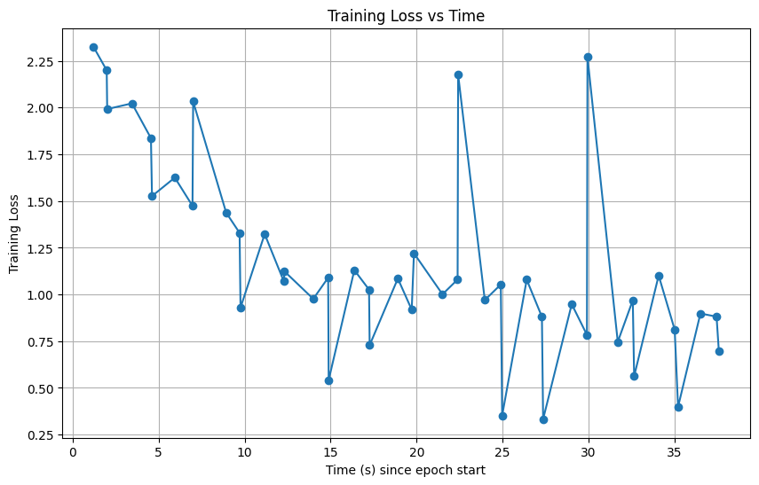

```python
plt.figure(figsize=(10, 6))
plt.plot(times, losses, marker='o')
plt.xlabel('Time (s) since epoch start')
plt.ylabel('Training Loss')
plt.title('Training Loss vs Time')
plt.grid(True)
plt.show()
```

## Test

```python
from sklearn.metrics import confusion_matrix
```

```python
pointnet = PointNet()
pointnet.load_state_dict(torch.load('save_0.pth'))
pointnet.eval();
```

```python
all_preds = []
all_labels = []
with torch.no_grad():
    for i, data in enumerate(valid_loader):
        print('Batch [%4d / %4d]' % (i+1, len(valid_loader)))

        inputs, labels = data['pointcloud'].float(), data['category']
        outputs, __, __ = pointnet(inputs.transpose(1,2))
        _, preds = torch.max(outputs.data, 1)
        all_preds += list(preds.numpy())
        all_labels += list(labels.numpy())
```

```
Batch [   1 /    1]
```

```python
cm = confusion_matrix(all_labels, all_preds);
cm
```

```
array([[ 0,  0,  4],
       [ 0,  0,  5],
       [ 0,  0, 16]])
```

```python
import itertools
import numpy as np
import matplotlib.pyplot as plt

# function from https://deeplizard.com/learn/video/0LhiS6yu2qQ
def plot_confusion_matrix(cm, classes, normalize=False, title='Confusion matrix', cmap=plt.cm.Blues):
    if normalize:
        cm = cm.astype('float') / cm.sum(axis=1)[:, np.newaxis]
        print("Normalized confusion matrix")
    else:
        print('Confusion matrix, without normalization')

    plt.imshow(cm, interpolation='nearest', cmap=cmap)
    plt.title(title)
    plt.colorbar()
    tick_marks = np.arange(len(classes))
    plt.xticks(tick_marks, classes, rotation=45)
    plt.yticks(tick_marks, classes)

    fmt = '.2f' if normalize else 'd'
    thresh = cm.max() / 2.
    for i, j in itertools.product(range(cm.shape[0]), range(cm.shape[1])):
        plt.text(j, i, format(cm[i, j], fmt), horizontalalignment="center", color="white" if cm[i, j] > thresh else "black")

    plt.tight_layout()
    plt.ylabel('True label')
    plt.xlabel('Predicted label')
```

```
Normalized confusion matrix
```

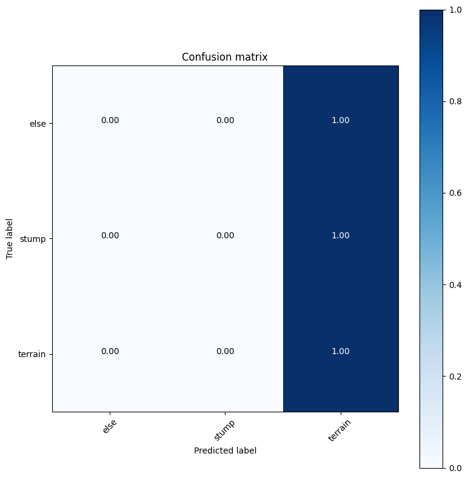

```python
plt.figure(figsize=(8,8))
plot_confusion_matrix(cm, list(classes.keys()), normalize=True)
```

```
Confusion matrix, without normalization
```

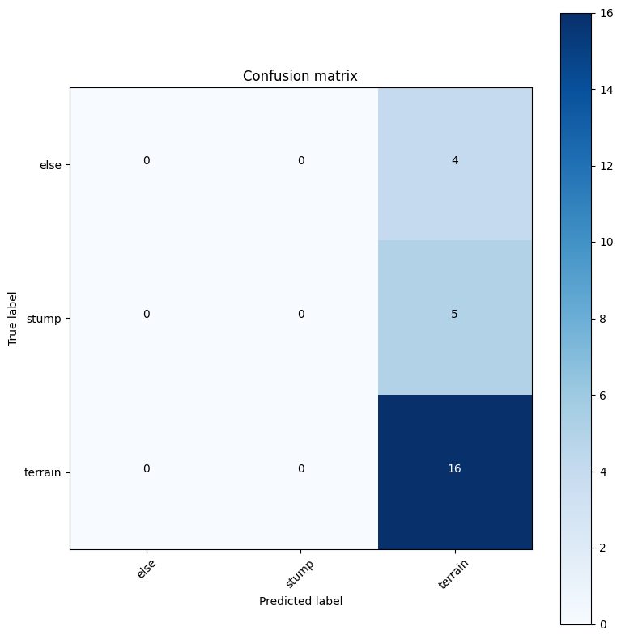

```python
plt.figure(figsize=(8,8))
plot_confusion_matrix(cm, list(classes.keys()), normalize=False)
```